# COMPSCIX 415.2 Homework 5/Midterm

Inessa Wu

February 28, 2018

#### GitHub repository: https://github.com/InessaWu/compscix-415-2-assignments

```r
library(tidyverse)
library (rmarkdown)
```

### The tidyverse Packages

#### Question 1

The following packages are associated with each task below:

Plotting - ggplot2 Data munging/wrangling - dplyr Reshaping (speading and gathering) data - tidyr Importing/exporting data - readr

#### Question 2

Below are few functions that I’ve used from each of the package listed in Question 1 for the tasks below:

Plotting - ggplot(), geom_point(), aes(), coord_flip() Data munging/wrangling - select(), filter(), mutate(), summarise(), arrange() Reshaping data - gather(), spread(), separate(), unite() Importing/exporting data (note that readRDS and saveRDS are base R functions) - read_csv(), read_delim()

### R Basics

#### Question 1

This code: My_data.name___is.too00ooLong! <- c( 1 , 2 , 3 ) should be fixed by removing the exclamation sign, as follows:

```r
My_data.name___is.too00ooLong <- c( 1 , 2   , 3 )
My_data.name___is.too00ooLong
```

```
## [1] 1 2 3
```

#### Question 2

This code: my_string <- C(‘has’, ‘an’, ‘error’, ‘in’, ‘it) should be fixed by changing “C”" to lower case “c” and adding’ after it, as follows:

```r
my_string <- c('has', 'an', 'error', 'in', 'it')
my_string
```

```
## [1] "has"   "an"    "error" "in"    "it"
```

#### Question 3

Code below outputs character/string data type, not integers data type

```r
my_vector <- c(1, 2, '3', '4', 5)
my_vector
```

```
## [1] "1" "2" "3" "4" "5"
```

### Data Import/Export

#### Question 1

Downloading the rail_trail.txt file from Canvas (in the Midterm Exam section here) and importing it into R.

```r
file_path <- 'C:/Users/ipodvorna/Documents/compscix-415-2-assignments/compscix-415-2-assignments/rail_trail.txt'
rail_trail_data <- read_delim(file = file_path, delim = "|")
```

Taking a glimpse at the imported rail_trail_data file

```r
glimpse(rail_trail_data)
```

```
## Observations: 90
## Variables: 10
## $ hightemp   <int> 83, 73, 74, 95, 44, 69, 66, 66, 80, 79, 78, 65, 41,...
## $ lowtemp    <int> 50, 49, 52, 61, 52, 54, 39, 38, 55, 45, 55, 48, 49,...
## $ avgtemp    <dbl> 66.5, 61.0, 63.0, 78.0, 48.0, 61.5, 52.5, 52.0, 67....
## $ spring     <int> 0, 0, 1, 0, 1, 1, 1, 1, 0, 0, 0, 1, 1, 0, 0, 1, 0, ...
## $ summer     <int> 1, 1, 0, 1, 0, 0, 0, 0, 1, 1, 1, 0, 0, 0, 0, 0, 1, ...
## $ fall       <int> 0, 0, 0, 0, 0, 0, 0, 0, 0, 0, 0, 0, 0, 1, 1, 0, 0, ...
## $ cloudcover <dbl> 7.6, 6.3, 7.5, 2.6, 10.0, 6.6, 2.4, 0.0, 3.8, 4.1, ...
## $ precip     <dbl> 0.00, 0.29, 0.32, 0.00, 0.14, 0.02, 0.00, 0.00, 0.0...
## $ volume     <int> 501, 419, 397, 385, 200, 375, 417, 629, 533, 547, 4...
## $ weekday    <int> 1, 1, 1, 0, 1, 1, 1, 0, 0, 1, 1, 1, 1, 1, 1, 1, 0, ...
```

#### Question 2

Exporting the file into an R-specific format:

```r
saveRDS(rail_trail_data, file = 'C:/Users/ipodvorna/Documents/compscix-415-2-assignments/compscix-415-2-assignments/rail_trail.rds')
```

Reload rail_trail.rds file.

```r
rail_trail_data_R <- readRDS('C:/Users/ipodvorna/Documents/compscix-415-2-assignments/compscix-415-2-assignments/rail_trail.rds')
```

Taking a glimpse

```r
glimpse(rail_trail_data_R)
```

```
## Observations: 90
## Variables: 10
## $ hightemp   <int> 83, 73, 74, 95, 44, 69, 66, 66, 80, 79, 78, 65, 41,...
## $ lowtemp    <int> 50, 49, 52, 61, 52, 54, 39, 38, 55, 45, 55, 48, 49,...
## $ avgtemp    <dbl> 66.5, 61.0, 63.0, 78.0, 48.0, 61.5, 52.5, 52.0, 67....
## $ spring     <int> 0, 0, 1, 0, 1, 1, 1, 1, 0, 0, 0, 1, 1, 0, 0, 1, 0, ...
## $ summer     <int> 1, 1, 0, 1, 0, 0, 0, 0, 1, 1, 1, 0, 0, 0, 0, 0, 1, ...
## $ fall       <int> 0, 0, 0, 0, 0, 0, 0, 0, 0, 0, 0, 0, 0, 1, 1, 0, 0, ...
## $ cloudcover <dbl> 7.6, 6.3, 7.5, 2.6, 10.0, 6.6, 2.4, 0.0, 3.8, 4.1, ...
## $ precip     <dbl> 0.00, 0.29, 0.32, 0.00, 0.14, 0.02, 0.00, 0.00, 0.0...
## $ volume     <int> 501, 419, 397, 385, 200, 375, 417, 629, 533, 547, 4...
## $ weekday    <int> 1, 1, 1, 0, 1, 1, 1, 0, 0, 1, 1, 1, 1, 1, 1, 1, 0, ...
```

### Visualization

#### Question 2

Reproducing graphic using the diamonds data set:

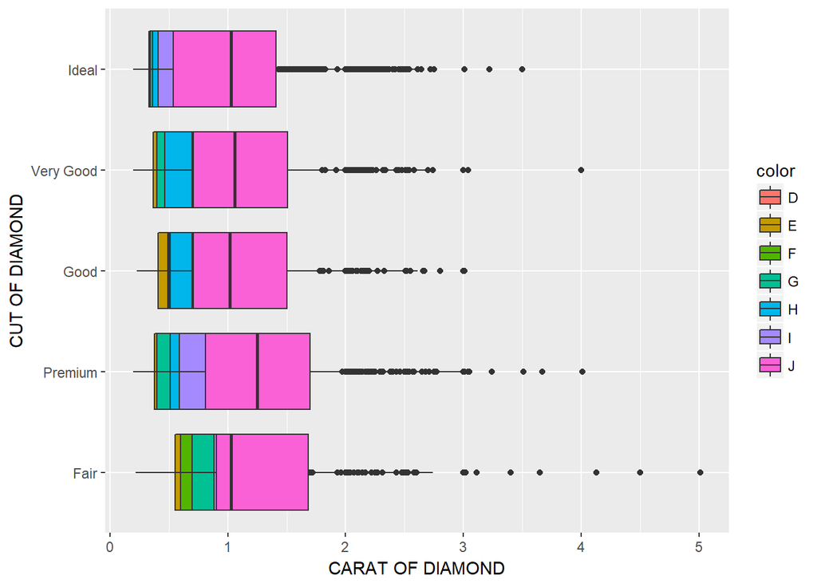

```r
ggplot(data=diamonds)+
  geom_boxplot(mapping = aes(x=(reorder(cut,-carat, FUN=mean)), y=carat, fill=color), position="identity")+
  labs(x="CUT OF DIAMOND", y="CARAT OF DIAMOND")+
  coord_flip()
```

#### Question 3

By chaging position to “dodge”, graph now shows separate box plots for each color of diamond within each cut category instead oflayering them

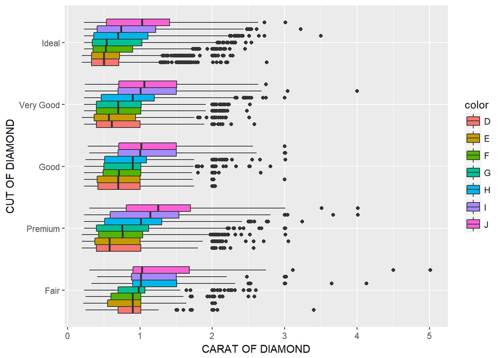

```r
ggplot(data=diamonds)+
  geom_boxplot(mapping = aes(x=(reorder(cut,-carat, FUN=mean)), y=carat, fill=color), position="dodge")+
  labs(x="CUT OF DIAMOND", y="CARAT OF DIAMOND")+
  coord_flip()
```

### Data munging and wrangling

#### Question 1

table2 dataset is not tidy.It contains “cases” and “population” variables combined in the same column under “type” header. The data set needs to be spread to seprate “cases” and “population” variables.

```r
table2_tidy <-
  spread(table2, type, count)

print(table2_tidy)
```

```
## # A tibble: 6 x 4
##   country      year  cases population
##   <chr>       <int>  <int>      <int>
## 1 Afghanistan  1999    745   19987071
## 2 Afghanistan  2000   2666   20595360
## 3 Brazil       1999  37737  172006362
## 4 Brazil       2000  80488  174504898
## 5 China        1999 212258 1272915272
## 6 China        2000 213766 1280428583
```

#### Question 3

Code for getting number of diamonds, and the applicable proportion with price > 10000 and a carat < 1.5

```r
diamonds %>% summarise(number_of_diamonds = sum(price > 10000 & carat < 1.5),
            prop_diamonds = mean(price > 10000 & carat < 1.5))
```

```
## # A tibble: 1 x 2
##   number_of_diamonds prop_diamonds
##                <int>         <dbl>
## 1                834        0.0155
```

### EDA

#### Question 1

txhousing data set covers data from January 2000 to July 2015

```r
txhousing %>%
  unite(year_month, year, month) %>%
  summarize (min(year_month), max(year_month), min(date), max(date))
```

```
## # A tibble: 1 x 4
##   `min(year_month)` `max(year_month)` `min(date)` `max(date)`
##   <chr>             <chr>                   <dbl>       <dbl>
## 1 2000_1            2015_7                   2000        2016
```

#### Question 2

txhousing dataset has 46 cities represented

```r
txhousing %>%
  summarise( count_dist=n_distinct(city))
```

```
## # A tibble: 1 x 1
##   count_dist
##        <int>
## 1         46
```

#### Question 3

Houston in July of 2015 had the highest number of sales

```r
txhousing %>%
  unite(year_month, year, month) %>%
  group_by(city, year_month) %>%
    summarize (number_sales = sum(sales)) %>%
  arrange(desc(number_sales))
```

```
## # A tibble: 8,602 x 3
## # Groups:   city [46]
##    city    year_month number_sales
##    <chr>   <chr>             <dbl>
##  1 Houston 2015_7             8945
##  2 Houston 2006_6             8628
##  3 Houston 2013_7             8468
##  4 Houston 2015_6             8449
##  5 Houston 2013_5             8439
##  6 Houston 2014_6             8391
##  7 Houston 2014_7             8391
##  8 Houston 2014_8             8167
##  9 Houston 2013_8             8155
## 10 Houston 2006_5             8040
## # ... with 8,592 more rows
```

#### Question 4

There is a linear relationships between sales and listings (values are correlated) - Sales increase with the increase in number of listings.

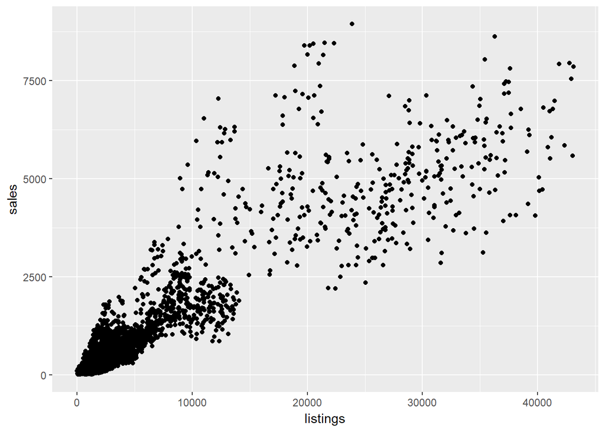

```r
txhousing %>% ggplot()+
geom_point (mapping=aes(x=listings, y=sales))
```

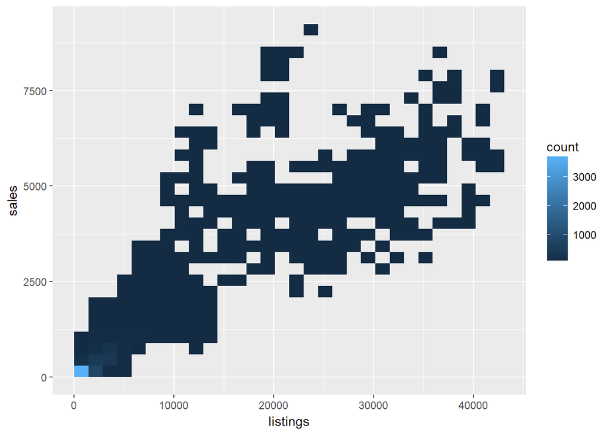

```r
txhousing %>%
  ggplot()+
  geom_bin2d(mapping=aes(x=listings, y=sales))
```

#### Question 5

Sales are missing for 568 records (6.6%). Detail by city is shown below with South Padre Island having the largest number proportion of sales records missing at 62%

```r
txhousing %>%
  summarize (sales_missing = sum(is.na(sales)),
             prop_missing = mean(is.na(sales)))
```

```
## # A tibble: 1 x 2
##   sales_missing prop_missing
##           <int>        <dbl>
## 1           568       0.0660
```

```r
txhousing %>%
  group_by(city) %>%
  summarize (sales_missing = sum(is.na(sales)),
             prop_missing = mean(is.na(sales))) %>%
  arrange (desc(prop_missing))
```

```
## # A tibble: 46 x 3
##    city               sales_missing prop_missing
##    <chr>                      <int>        <dbl>
##  1 South Padre Island           116       0.620
##  2 Kerrville                    104       0.556
##  3 Midland                       75       0.401
##  4 Odessa                        72       0.385
##  5 San Marcos                    46       0.246
##  6 Laredo                        36       0.193
##  7 Harlingen                     25       0.134
##  8 Waco                          19       0.102
##  9 Texarkana                     17       0.0909
## 10 Brazoria County               14       0.0749
## # ... with 36 more rows
```

#### Question 6

Distribution of the median sales price when grouped by city differ, as shown on the boxplot below. City with large number of outliers, such as Dallas, Houston, and COllin County would warrant more investigation.

Filter of greater than 500 sales is useful to cut the noise and be able to clearly look at and interpret the results.

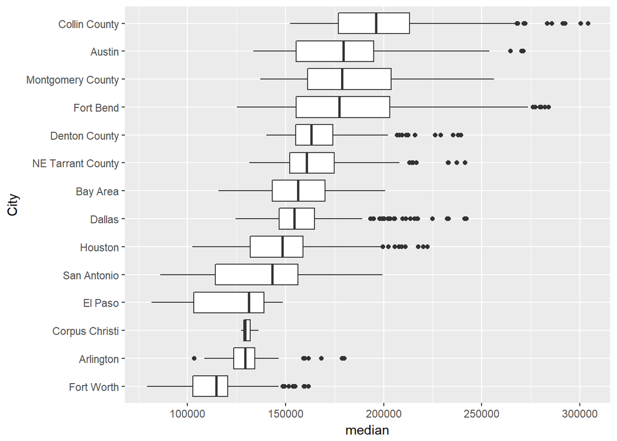

```r
txhousing %>%
  unite(year_month, year, month, remove=FALSE) %>%
  group_by(year_month) %>%
  filter (sales > 500) %>%

  ggplot()+
  geom_boxplot(mapping=aes(x=reorder(city, median, FUN=median.default), y=median))+
  labs(x="City")+
  coord_flip()
```